# Data Analisys part 2

lession 4c lubridate

Eviatar Guttman

Last updated: 14-06-2021

```r
library(tidyverse)
library(nycflights13)
library(lubridate)
```

There are three types of date/time data that refer to an instant in time:

1. A date. Tibbles print this as `<date>`.
2. A time within a day. Tibbles print this as `<time>`.
3. A date-time is a date plus a time: it uniquely identifies an instant in time (typically to the nearest second). Tibbles print this as `<dttm>`. Elsewhere in R these are called POSIXct.

```r
today()
```

```
## [1] "2021-06-14"
```

```r
attributes(today())
```

```
## $class
## [1] "Date"
```

```r
typeof(today())
```

```
## [1] "double"
```

```r
now()
```

```
## [1] "2021-06-14 17:14:20 IDT"
```

```r
attributes(now())
```

```
## $class
## [1] "POSIXct" "POSIXt"
##
## $tzone
## [1] ""
```

```r
typeof(now())
```

```
## [1] "double"
```

There are three ways you’re likely to create a date/time:

1. From a string.
2. From individual date-time components.
3. From an existing date/time object.

# from strings

Here are a banch of functions that Transforms dates stored in character and numeric vectors to Date or POSIXct objects:

```r
ymd("2017-01-31")
```

```
## [1] "2017-01-31"
```

```r
ymd("2017/01/31")
```

```
## [1] "2017-01-31"
```

```r
mdy("January 31st, 2017")
```

```
## [1] "2017-01-31"
```

```r
dmy("31-Jan-2017")
```

```
## [1] "2017-01-31"
```

```r
x <- c(20090101, "2009-01-02", "2009 01 03", "2009-1-4",
       "2009-1, 5", "Created on 2009 1 6", "200901 !!! 07")
ymd(x)
```

```
## [1] "2009-01-01" "2009-01-02" "2009-01-03" "2009-01-04" "2009-01-05"
## [6] "2009-01-06" "2009-01-07"
```

```r
ymd_hms("2017-01-31 20:11:59")
```

```
## [1] "2017-01-31 20:11:59 UTC"
```

```r
mdy_hm("01/31/2017 08:01")
```

```
## [1] "2017-01-31 08:01:00 UTC"
```

# From individual components

`make_date()` produces objects of class `Date`

```r
make_date(year = 1970L, month = 1L, day = 1L)
```

```
## [1] "1970-01-01"
```

like most functions in R, `make_date` is vectorized:

```r
flights %>%
  select(year, month, day) %>%
  mutate(departure = make_date(year, month, day))
```

```
## # A tibble: 336,776 x 4
##     year month   day departure
##    <int> <int> <int> <date>
##  1  2013     1     1 2013-01-01
##  2  2013     1     1 2013-01-01
##  3  2013     1     1 2013-01-01
##  4  2013     1     1 2013-01-01
##  5  2013     1     1 2013-01-01
##  6  2013     1     1 2013-01-01
##  7  2013     1     1 2013-01-01
##  8  2013     1     1 2013-01-01
##  9  2013     1     1 2013-01-01
## 10  2013     1     1 2013-01-01
## # ... with 336,766 more rows
```

```r
flights %>%
  select(year, month, day, hour, minute) %>%
  mutate(departure = make_datetime(year, month, day, hour, minute))
```

```
## # A tibble: 336,776 x 6
##     year month   day  hour minute departure
##    <int> <int> <int> <dbl>  <dbl> <dttm>
##  1  2013     1     1     5     15 2013-01-01 05:15:00
##  2  2013     1     1     5     29 2013-01-01 05:29:00
##  3  2013     1     1     5     40 2013-01-01 05:40:00
##  4  2013     1     1     5     45 2013-01-01 05:45:00
##  5  2013     1     1     6      0 2013-01-01 06:00:00
##  6  2013     1     1     5     58 2013-01-01 05:58:00
##  7  2013     1     1     6      0 2013-01-01 06:00:00
##  8  2013     1     1     6      0 2013-01-01 06:00:00
##  9  2013     1     1     6      0 2013-01-01 06:00:00
## 10  2013     1     1     6      0 2013-01-01 06:00:00
## # ... with 336,766 more rows
```

# From other types

You may want to switch between a date-time and a date. That’s the job of `as_datetime()` and `as_date()`:

```r
as_datetime(today())
```

```
## [1] "2021-06-14 UTC"
```

```r
as_date(now())
```

```
## [1] "2021-06-14"
```

Sometimes you’ll get date/times as numeric offsets from the “Unix Epoch”, 1970-01-01.  
If the offset is in seconds, use `as_datetime()`; if it’s in days, use `as_date()`.

```r
60 * 60 * 10 # 10 hours
```

```
## [1] 36000
```

```r
as_datetime(60 * 60 * 10)
```

```
## [1] "1970-01-01 10:00:00 UTC"
```

```r
365 * 10 + 2 # 10 years
```

```
## [1] 3652
```

```r
as_date(365 * 10 + 2)
```

```
## [1] "1980-01-01"
```

# Useful functions

```r
some_time <- ymd_hms("2016-07-08 12:34:56")

year(some_time)
```

```
## [1] 2016
```

```r
month(some_time)
```

```
## [1] 7
```

```r
month(some_time, label = T)
```

```
## [1] יול
## 12 Levels: ינו < פבר < מרץ < אפר < מאי < יונ < יול < אוג < ספט < ... < דצמ
```

```r
month(some_time, label = T, abbr = F)
```

```
## [1] יולי
## 12 Levels: ינואר < פברואר < מרץ < אפריל < מאי < יוני < יולי < ... < דצמבר
```

This happens because we set: `Sys.setlocale("LC_ALL", "hebrew")` (I think). there is a function called `local()` that reads the days and time from you system locality.

```r
locale()
## <locale>
## Numbers:  123,456.78
## Formats:  %AD / %AT
## Timezone: UTC
## Encoding: UTF-8
## <date_names>
## Days:   Sunday (Sun), Monday (Mon), Tuesday (Tue), Wednesday (Wed), Thursday
##         (Thu), Friday (Fri), Saturday (Sat)
## Months: January (Jan), February (Feb), March (Mar), April (Apr), May (May),
##         June (Jun), July (Jul), August (Aug), September (Sep), October
##         (Oct), November (Nov), December (Dec)
## AM/PM:  AM/PM

locale('he')
## <locale>
## Numbers:  123,456.78
## Formats:  %AD / %AT
## Timezone: UTC
## Encoding: UTF-8
## <date_names>
## Days:   יום ראשון (יום א׳), יום שני (יום ב׳), יום שלישי (יום ג׳), יום רביעי
##         (יום ד׳), יום חמישי (יום ה׳), יום שישי (יום ו׳), יום שבת (שבת)
## Months: ינואר (ינו׳), פברואר (פבר׳), מרץ (מרץ), אפריל (אפר׳), מאי (מאי), יוני
##         (יוני), יולי (יולי), אוגוסט (אוג׳), ספטמבר (ספט׳), אוקטובר
##         (אוק׳), נובמבר (נוב׳), דצמבר (דצמ׳)
## AM/PM:  לפנה״צ/אחה״צ
```

count number of X since the beginning

```r
mday(some_time) # מספר ימים מתחילת החודש
```

```
## [1] 8
```

```r
yday(some_time) # מספר ימים מתחילת שנה
```

```
## [1] 190
```

```r
wday(some_time) # יום שישי
```

```
## [1] 6
```

```r
wday(some_time, label = T)
```

```
## [1] יום ו
## Levels: יום א < יום ב < יום ג < יום ד < יום ה < יום ו < שבת
```

its an ordered factor. we haven’t talked about it yet.

```r
attributes(wday(some_time, label = T))
```

```
## $levels
## [1] "יום א" "יום ב" "יום ג" "יום ד" "יום ה" "יום ו" "שבת"
##
## $class
## [1] "ordered" "factor"
```

We can use wday() to see that more flights depart during the week than on the weekend

```r
names(flights)
```

```
##  [1] "year"           "month"          "day"            "dep_time"
##  [5] "sched_dep_time" "dep_delay"      "arr_time"       "sched_arr_time"
##  [9] "arr_delay"      "carrier"        "flight"         "tailnum"
## [13] "origin"         "dest"           "air_time"       "distance"
## [17] "hour"           "minute"         "time_hour"
```

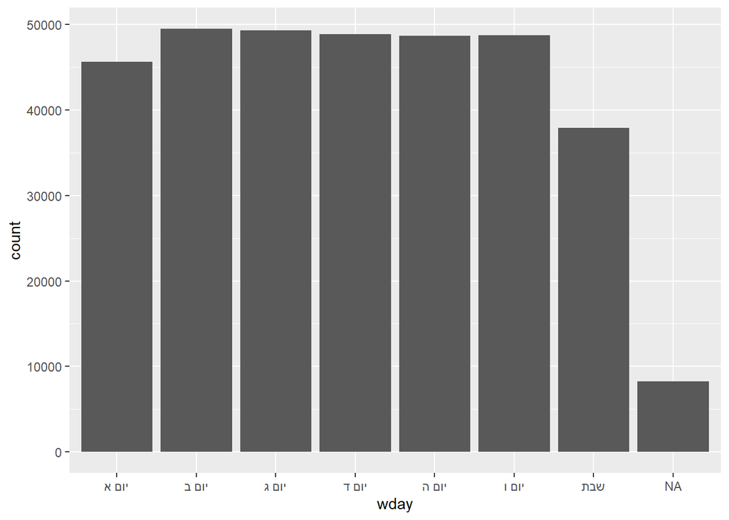

```r
flights %>% select(year, month, day, dep_time  ) %>%
  mutate(departure = make_datetime(year, month, day, dep_time %/% 100, dep_time %% 100)) %>%
  mutate(wday = wday(departure, label = T)) %>%
  ggplot(aes(x = wday))+ geom_bar()
```

we need to check about NA’s in the data!

Very useful is : `floor_date`, `round_date`, `ceiling_date`

```r
(x <- ymd_hms("2009-08-03 12:01:59.23"))
```

```
## [1] "2009-08-03 12:01:59 UTC"
```

```r
round_date(x, "second")
```

```
## [1] "2009-08-03 12:01:59 UTC"
```

```r
round_date(x, "minute")
```

```
## [1] "2009-08-03 12:02:00 UTC"
```

```r
round_date(x, "5 mins")
```

```
## [1] "2009-08-03 12:00:00 UTC"
```

```r
round_date(x, "2 hours")
```

```
## [1] "2009-08-03 12:00:00 UTC"
```

```r
round_date(x, "bimonth")
```

```
## [1] "2009-09-01 UTC"
```

```r
round_date(x, "quarter") == round_date(x, "3 months")
```

```
## [1] TRUE
```

```r
round_date(x, "halfyear")
```

```
## [1] "2009-07-01 UTC"
```

```r
round_date(x, "year")
```

```
## [1] "2010-01-01 UTC"
```

# difftime

there is also a timediff format:

```r
arrive <- ymd_hms("2011-06-04 12:00:00", tz = "Pacific/Auckland")

leave <- ymd_hms("2011-08-10 14:00:00", tz = "Pacific/Auckland")

(time_diff <- interval(arrive, leave))
```

```
## [1] 2011-06-04 12:00:00 NZST--2011-08-10 14:00:00 NZST
```

```r
attributes(time_diff)
```

```
## $start
## [1] "2011-06-04 12:00:00 NZST"
##
## $tzone
## [1] "Pacific/Auckland"
##
## $class
## [1] "Interval"
## attr(,"package")
## [1] "lubridate"
```

number of days differnce:

```r
time_diff / ddays(1)
```

```
## [1] 67.08333
```

```r
time_diff / ddays(3)
```

```
## [1] 22.36111
```

```r
time_diff / dweeks()
```

```
## [1] 9.583333
```

number of month diff:

```r
time_diff / dmonths()
```

```
## [1] 2.20397
```

# exercises

1. מה קורה אם מנסים לעשות parse ל-string שמכיל תאריכים לא תקפים?

`ymd(c("2010-10-10", "bananas"))`

2. מה התפקיד של הארגומנט `tzone` בפונקציה `today`? מדוע הוא חשוב?
3. השתמש בפונקציות המתאימות ב-`lubridate` כדי לעשות parse לתאריכים הבאים:

```r
d1 <- "January 1, 2010"
d2 <- "2015-Mar-07"
d3 <- "06-Jun-2017"
d4 <- c("August 19 (2015)", "July 1 (2015)")
d5 <- "12/30/14" # Dec 30, 2014
```

4. איך ההתפלגות של שעות הטיסה משתנות לאורך השנה?
5. באיזה יום בשבוע כדאי לטוס אם רוצים למזער את ההסתברות לאיחור?